# Tugas Pertemuan 2 - Metode Pemulusan Deret Waktu

2026-08-30

# Library

```r
library(forecast)
```

```r
library(graphics)
library(TTR)
library(rio)
library(ggplot2)
```

# Data

```r
data_ces <- import ("C:\\Users\\Rafael Dominico\\Pictures\\Kuliah\\Semester 5\\Metode Peramalan Deret Waktu\\mpdw.xlsx")
head (data_ces)
```

```
##   observation_date Period CES9093161101
## 1       1997-09-01    513        6804.0
## 2       1997-10-01    514        6821.0
## 3       1997-11-01    515        6827.4
## 4       1997-12-01    516        6836.9
## 5       1998-01-01    517        6849.3
## 6       1998-02-01    518        6867.5
```

# Eksplorasi Data

```r
View(data_ces)
str(data_ces)
```

```
## 'data.frame':    170 obs. of  3 variables:
##  $ observation_date: POSIXct, format: "1997-09-01" "1997-10-01" ...
##  $ Period          : num  513 514 515 516 517 518 519 520 521 522 ...
##  $ CES9093161101   : num  6804 6821 6827 6837 6849 ...
```

```r
dim(data_ces)
```

```
## [1] 170   3
```

```r
data_ces.ts <- ts(data_ces$CES9093161101, start = c(1997, 9), frequency = 12)
summary(data_ces.ts)
```

```
##    Min. 1st Qu.  Median    Mean 3rd Qu.    Max.
##    6804    7434    7781    7674    7961    8119
```

# Plot deret waktu

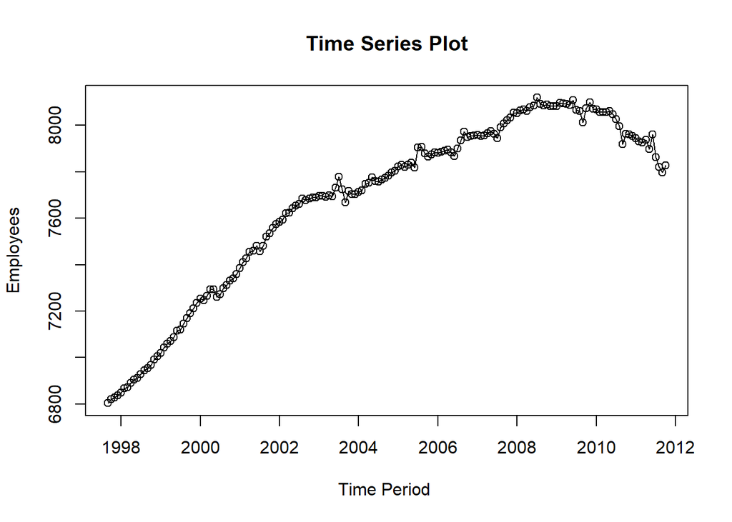

```r
ts.plot(data_ces.ts, xlab="Time Period ", ylab="Employees",
main = "Time Series Plot")
points(data_ces.ts)
```

```r
dev.copy(png, "plot_data_ces.png")
```

```r
dev.off()
```

# Moving Average

```r
# jumlah data
n <- nrow(data_ces)

# tentukan batas 80%
n_train <- floor(0.8 * n)

# bagi data
training_ma <- data_ces[1:n_train, ]
testing_ma  <- data_ces[(n_train+1):n, ]

# ubah ke time series
train_ma.ts <- ts(
  training_ma$CES9093161101,
  frequency = 12
)

test_ma.ts <- ts(
  testing_ma$CES9093161101,
  frequency = 12
)
```

Eksplorasi data dilakukan pada keseluruhan data, data latih serta data uji menggunakan plot data deret waktu.

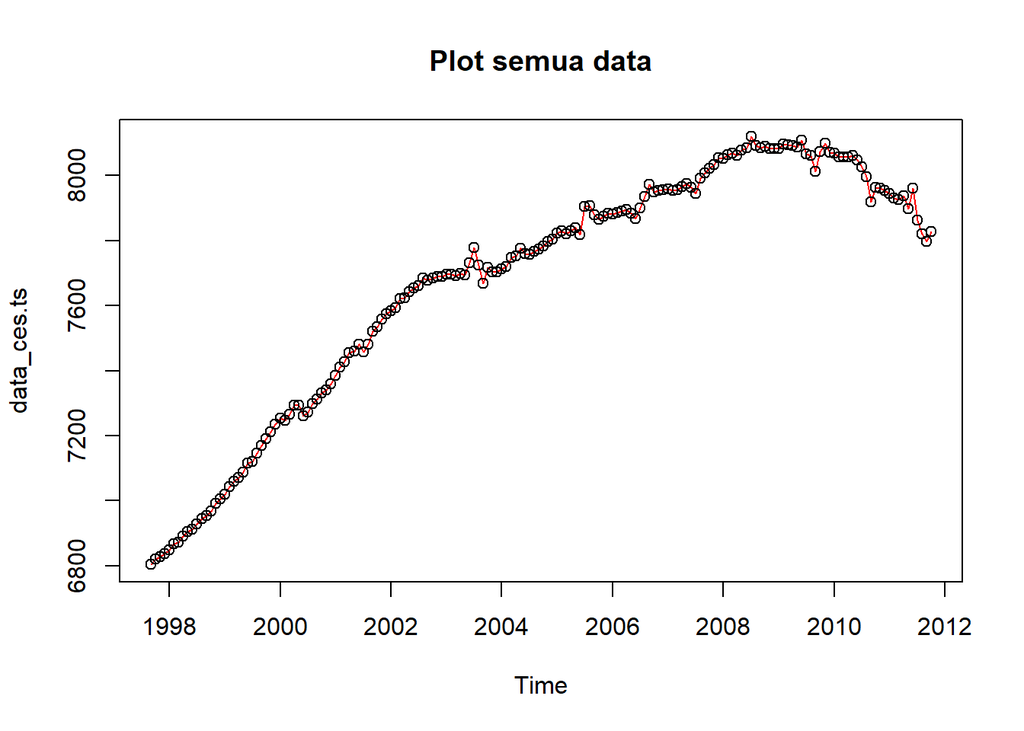

```r
#eksplorasi keseluruhan data
plot(data_ces.ts, col="red",main="Plot semua data")
points(data_ces.ts)
```

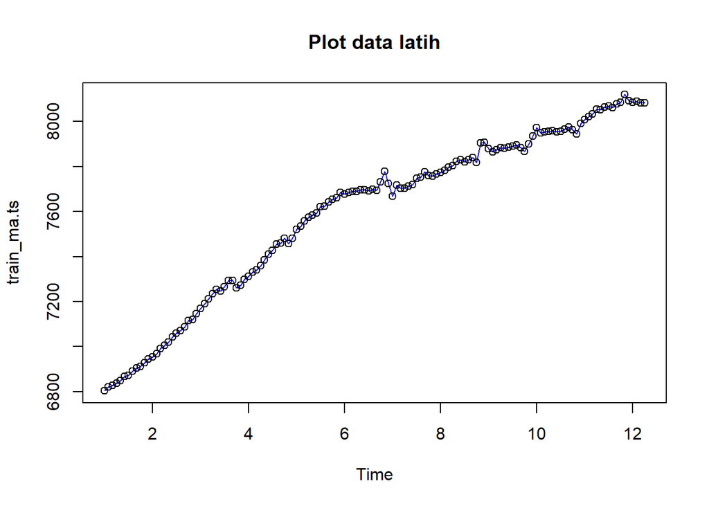

```r
#eksplorasi data latih
plot(train_ma.ts, col="blue",main="Plot data latih")
points(train_ma.ts)
```

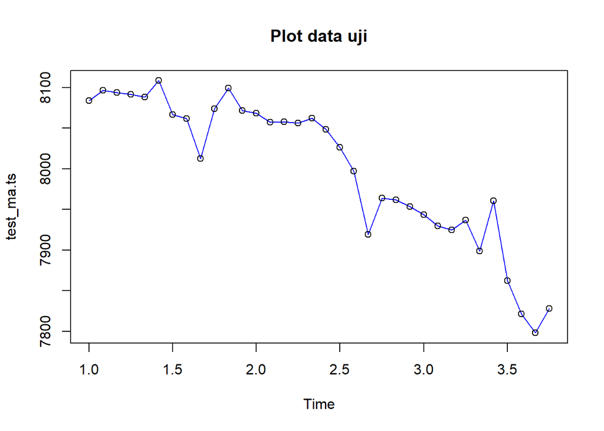

```r
#eksplorasi data uji
plot(test_ma.ts, col="blue",main="Plot data uji")
points(test_ma.ts)
```

Eksplorasi data juga dapat dilakukan menggunakan package `ggplot2` dengan terlebih dahulu memanggil library *package* `ggplot2`

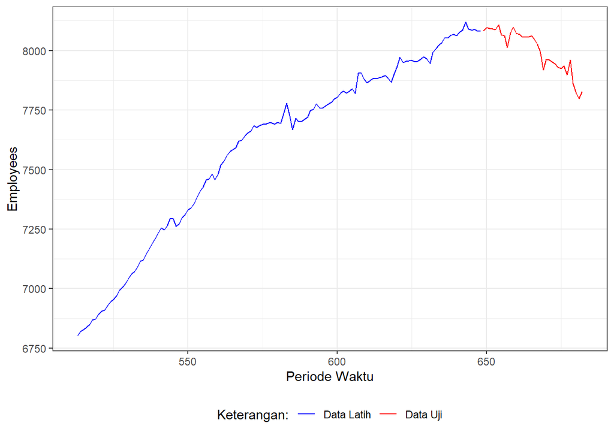

```r
ggplot() +
  geom_line(data = training_ma, aes(x = Period, y = CES9093161101, col = "Data Latih")) +
  geom_line(data = testing_ma, aes(x = Period, y = CES9093161101
, col = "Data Uji")) +
  labs(x = "Periode Waktu", y = "Employees", color = "Legend") +
   scale_colour_manual(name="Keterangan:", breaks = c("Data Latih", "Data Uji"),
                      values = c("blue", "red")) +
  theme_bw() + theme(legend.position = "bottom",
                     plot.caption = element_text(hjust=0.5, size=12))
```

# Simple Moving Average (SMA)

Ide dasar dari Single Moving Average (SMA) adalah data suatu periode dipengaruhi oleh data periode sebelumnya. Metode pemulusan ini cocok digunakan untuk pola data stasioner atau konstan. Prinsip dasar metode pemulusan ini adalah data pemulusan pada periode ke-t merupakan rata rata dari m buah data pada periode ke-t hingga periode ke (t-m+1).

$$S_t = \frac{1}{m} \sum_{i=t-m+1}^{t} X_i$$
$$S_t = \frac{1}{m}
\sum_{i=t-m+1}^{t} X_i$$

Data pemulusan pada periode ke-t selanjutnya digunakan sebagai nilai peramalan pada periode ke t+1.

$$F_t = S_{t-1}, F_{n,h} =
S_n$$

Pemulusan menggunakan metode SMA dilakukan dengan fungsi `SMA()`. Dalam hal ini akan dilakukan pemulusan dengan parameter `m=4`.

```r
data.sma<-SMA(train_ma.ts, n=4)
data.sma
```

```
##         Jan      Feb      Mar      Apr      May      Jun      Jul      Aug
## 1        NA       NA       NA 6822.325 6833.650 6845.275 6856.625 6870.250
## 2  6934.475 6949.000 6965.100 6980.500 6996.875 7015.375 7032.225 7048.825
## 3  7137.475 7156.250 7179.025 7201.400 7222.850 7236.775 7250.225 7264.675
## 4  7286.100 7303.225 7320.050 7335.450 7353.675 7373.750 7395.575 7419.725
## 5  7485.025 7498.700 7523.900 7547.400 7563.325 7577.750 7593.500 7605.475
## 6  7669.675 7677.075 7684.250 7685.675 7690.750 7693.900 7694.050 7696.125
## 7  7725.825 7722.075 7702.925 7697.400 7708.525 7709.375 7720.825 7733.500
## 8  7764.850 7770.375 7780.375 7789.450 7801.350 7813.425 7819.275 7825.825
## 9  7877.375 7888.825 7881.550 7875.475 7876.350 7881.925 7885.675 7888.950
## 10 7918.875 7939.475 7953.125 7958.525 7955.325 7956.100 7956.550 7958.700
## 11 7977.675 7992.275 8014.450 8030.175 8041.400 8051.825 8060.200 8062.025
## 12 8095.700 8096.600 8087.450 8085.375
##         Sep      Oct      Nov      Dec
## 1  6883.950 6894.900 6908.650 6921.850
## 2  7065.925 7083.875 7098.925 7117.325
## 3  7274.250 7278.275 7280.200 7281.450
## 4  7438.600 7456.200 7463.700 7469.925
## 5  7620.075 7635.450 7645.725 7661.075
## 6  7695.525 7704.050 7726.025 7732.700
## 7  7749.675 7759.875 7762.175 7765.450
## 8  7830.400 7827.325 7848.275 7867.750
## 9  7889.375 7884.600 7886.925 7896.700
## 10 7962.325 7965.150 7962.500 7969.100
## 11 8068.175 8073.550 8086.425 8093.900
## 12
```

Data pemulusan pada periode ke-t selanjutnya digunakan sebagai nilai peramalan pada periode ke t+1 sehingga hasil peramalan 1 periode kedepan adalah sebagai berikut.

```r
data.ramal<-c(NA,data.sma)
data.ramal #forecast 1 periode ke depan
```

```
##   [1]       NA       NA       NA       NA 6822.325 6833.650 6845.275 6856.625
##   [9] 6870.250 6883.950 6894.900 6908.650 6921.850 6934.475 6949.000 6965.100
##  [17] 6980.500 6996.875 7015.375 7032.225 7048.825 7065.925 7083.875 7098.925
##  [25] 7117.325 7137.475 7156.250 7179.025 7201.400 7222.850 7236.775 7250.225
##  [33] 7264.675 7274.250 7278.275 7280.200 7281.450 7286.100 7303.225 7320.050
##  [41] 7335.450 7353.675 7373.750 7395.575 7419.725 7438.600 7456.200 7463.700
##  [49] 7469.925 7485.025 7498.700 7523.900 7547.400 7563.325 7577.750 7593.500
##  [57] 7605.475 7620.075 7635.450 7645.725 7661.075 7669.675 7677.075 7684.250
##  [65] 7685.675 7690.750 7693.900 7694.050 7696.125 7695.525 7704.050 7726.025
##  [73] 7732.700 7725.825 7722.075 7702.925 7697.400 7708.525 7709.375 7720.825
##  [81] 7733.500 7749.675 7759.875 7762.175 7765.450 7764.850 7770.375 7780.375
##  [89] 7789.450 7801.350 7813.425 7819.275 7825.825 7830.400 7827.325 7848.275
##  [97] 7867.750 7877.375 7888.825 7881.550 7875.475 7876.350 7881.925 7885.675
## [105] 7888.950 7889.375 7884.600 7886.925 7896.700 7918.875 7939.475 7953.125
## [113] 7958.525 7955.325 7956.100 7956.550 7958.700 7962.325 7965.150 7962.500
## [121] 7969.100 7977.675 7992.275 8014.450 8030.175 8041.400 8051.825 8060.200
## [129] 8062.025 8068.175 8073.550 8086.425 8093.900 8095.700 8096.600 8087.450
## [137] 8085.375
```

```r
data.gab<-cbind(
  aktual=c(data_ces.ts),
  pemulusan=c(data.sma,rep(NA,34)),
  ramalan=c(data.ramal,rep(data.ramal[length(data.ramal)],34)))
data.gab #forecast 24 periode ke depan
```

```
##        aktual pemulusan  ramalan
##   [1,] 6804.0        NA       NA
##   [2,] 6821.0        NA       NA
##   [3,] 6827.4        NA       NA
##   [4,] 6836.9  6822.325       NA
##   [5,] 6849.3  6833.650 6822.325
##   [6,] 6867.5  6845.275 6833.650
##   [7,] 6872.8  6856.625 6845.275
##   [8,] 6891.4  6870.250 6856.625
##   [9,] 6904.1  6883.950 6870.250
##  [10,] 6911.3  6894.900 6883.950
##  [11,] 6927.8  6908.650 6894.900
##  [12,] 6944.2  6921.850 6908.650
##  [13,] 6954.6  6934.475 6921.850
##  [14,] 6969.4  6949.000 6934.475
```

[output cut: 157 more lines]

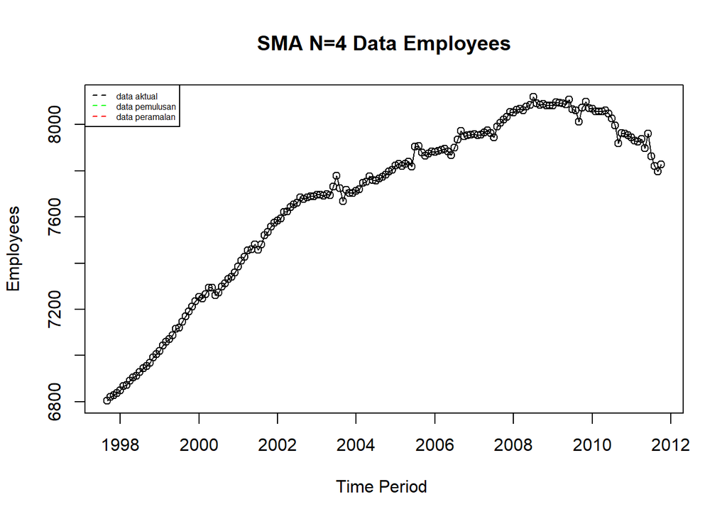

```r
ts.plot(data_ces.ts, xlab="Time Period ", ylab="Employees", main= "SMA N=4 Data Employees")
points(data_ces.ts)
lines(data.gab[,2],col="green",lwd=2)
lines(data.gab[,3],col="red",lwd=2)
legend("topleft",c("data aktual","data pemulusan","data peramalan"), lty=8, col=c("black","green","red"), cex=0.5)
```

Selanjutnya perhitungan akurasi dilakukan dengan ukuran akurasi *Sum Squares Error* (SSE), *Mean Square Error* (MSE) dan *Mean Absolute Percentage Error* (MAPE). Perhitungan akurasi dilakukan baik pada data latih maupun pada data uji.

$$SSE = \sum_{t=1}^{n} (y_t -
\hat{y}_t)^2$$
$$MSE = \frac{1}{n}
\sum_{t=1}^{n} (y_t - \hat{y}_t)^2$$
$$MAPE = \frac{1}{n} \sum_{t=1}^{n} \left|\frac{y_t
- \hat{y}_t}{y_t}\right| * 100$$

# Akurasi Data Latih

```r
#Menghitung nilai keakuratan data latih
error_train.sma = train_ma.ts-data.ramal[1:length(train_ma.ts)]

SSE_train.sma = sum(error_train.sma[5:length(train_ma.ts)]^2)
MSE_train.sma = mean(error_train.sma[5:length(train_ma.ts)]^2)
MAPE_train.sma = mean(abs((error_train.sma[5:length(train_ma.ts)]/train_ma.ts[5:length(train_ma.ts)])*100))

akurasi_train.sma <- matrix(c(SSE_train.sma, MSE_train.sma, MAPE_train.sma))
row.names(akurasi_train.sma)<- c("SSE", "MSE", "MAPE")
colnames(akurasi_train.sma) <- c("Akurasi m = 4")
akurasi_train.sma
```

```
##      Akurasi m = 4
## SSE   1.454354e+05
## MSE   1.101783e+03
## MAPE  3.650402e-01
```

# Akurasi Data Uji

```r
# Menghitung nilai keakuratan data uji
error_test.sma = test_ma.ts - data.gab[137:170, 3]

SSE_test.sma = sum(error_test.sma^2)
MSE_test.sma = mean(error_test.sma^2)
MAPE_test.sma = mean(abs((error_test.sma/test_ma.ts*100)))

akurasi_test.sma <- matrix(c(SSE_test.sma, MSE_test.sma, MAPE_test.sma))
row.names(akurasi_test.sma)<- c("SSE", "MSE", "MAPE")
colnames(akurasi_test.sma) <- c("Akurasi m = 4")
akurasi_test.sma
```

```
##      Akurasi m = 4
## SSE   5.097591e+05
## MSE   1.499292e+04
## MAPE  1.118581e+00
```

Perhitungan akurasi menggunakan data latih menghasilkan nilai MAPE yang kurang dari 10% sehingga nilai akurasi ini dapat dikategorikan sebagai sangat baik.

# Double Moving Average (DMA)

Metode pemulusan Double Moving Average (DMA) pada dasarnya mirip dengan SMA. Namun demikian, metode ini lebih cocok digunakan untuk pola data trend. Proses pemulusan dengan rata rata dalam metode ini dilakukan sebanyak 2 kali.

Metode pemulusan Double Moving Average (DMA) pada dasarnya mirip dengan SMA. Namun demikian, metode ini lebih cocok digunakan untuk pola data trend. Proses pemulusan dengan rata rata dalam metode ini dilakukan sebanyak 2 kali.

- **Tahap I:**

$$S_{1,t} = \frac{1}{m} \sum_{i=t-m+1}^{t}
X_i$$

- **Tahap II:**

$$S_{2,t} = \frac{1}{m} \sum_{i=t-m+1}^{t}
S_{1,i}$$

Forecast $h$ langkah ke depan dihitung dengan:

$$F_{2,t,t+h} = A_t + B_t
\,(h)$$

dengan komponen level ($A_t$) dan tren ($B_t$):

$$A_t = 2S_{1,t} - S_{2,t}
\qquad\text{dan}\qquad
B_t = \frac{2}{m-1}\,\big(S_{1,t} - S_{2,t}\big)$$

```r
dma <- SMA(data.sma, n = 4)
At <- 2*data.sma - dma
Bt <- 2/(4-1)*(data.sma - dma)
data.dma<- At+Bt
data.ramal2<- c(NA, data.dma)

t = 1:34
f = c()

for (i in t) {
  f[i] = At[length(At)] + Bt[length(Bt)]*(i)
}

data.gab2 <- cbind(aktual = c(data_ces.ts),
                   pemulusan1 = c(data.sma,rep(NA,24)),
                   pemulusan2 = c(dma, rep(NA,24)),
                   At = c(At, rep(NA,24)),
                   Bt = c(Bt,rep(NA,24)),
                   ramalan = c(data.ramal2, f[-1]))
data.gab2
```

```
##        aktual pemulusan1 pemulusan2       At          Bt  ramalan
##   [1,] 6804.0         NA         NA       NA          NA       NA
##   [2,] 6821.0         NA         NA       NA          NA       NA
##   [3,] 6827.4         NA         NA       NA          NA       NA
##   [4,] 6836.9   6822.325         NA       NA          NA       NA
##   [5,] 6849.3   6833.650         NA       NA          NA       NA
##   [6,] 6867.5   6845.275         NA       NA          NA       NA
##   [7,] 6872.8   6856.625   6839.469 6873.781  11.4375000       NA
##   [8,] 6891.4   6870.250   6851.450 6889.050  12.5333333 6885.219
##   [9,] 6904.1   6883.950   6864.025 6903.875  13.2833333 6901.583
##  [10,] 6911.3   6894.900   6876.431 6913.369  12.3125000 6917.158
##  [11,] 6927.8   6908.650   6889.438 6927.863  12.8083333 6925.681
##  [12,] 6944.2   6921.850   6902.338 6941.363  13.0083333 6940.671
##  [13,] 6954.6   6934.475   6914.969 6953.981  13.0041667 6954.371
##  [14,] 6969.4   6949.000   6928.494 6969.506  13.6708333 6966.985
```

[output cut: 156 more lines]

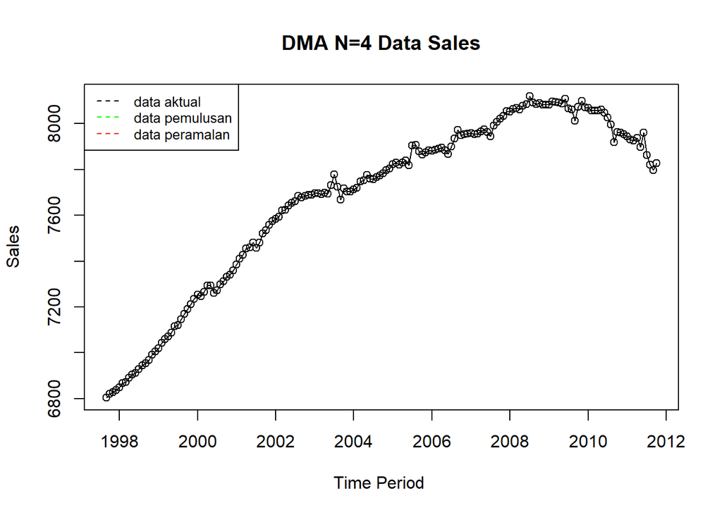

```r
ts.plot(data_ces.ts, xlab="Time Period ", ylab="Sales", main= "DMA N=4 Data Sales")
points(data_ces.ts)
lines(data.gab2[,3],col="green",lwd=2)
lines(data.gab2[,6],col="red",lwd=2)
legend("topleft",c("data aktual","data pemulusan","data peramalan"), lty=8, col=c("black","green","red"), cex=0.8)
```

Selanjutnya perhitungan akurasi dilakukan baik pada data latih maupun data uji. Perhitungan akurasi dilakukan dengan ukuran akurasi SSE, MSE dan MAPE.

# Akurasi Data Latih

```r
#Menghitung nilai keakuratan data latih
error_train.dma = train_ma.ts-data.ramal2[1:length(train_ma.ts)]

SSE_train.dma = sum(error_train.dma[8:length(train_ma.ts)]^2)
MSE_train.dma = mean(error_train.dma[8:length(train_ma.ts)]^2)
MAPE_train.dma = mean(abs((error_train.dma[8:length(train_ma.ts)]/train_ma.ts[8:length(train_ma.ts)])*100))

akurasi_train.dma <- matrix(c(SSE_train.dma, MSE_train.dma, MAPE_train.dma))
row.names(akurasi_train.dma)<- c("SSE", "MSE", "MAPE")
colnames(akurasi_train.dma) <- c("Akurasi m = 4")
akurasi_train.dma
```

```
##      Akurasi m = 4
## SSE   6.986528e+04
## MSE   5.415913e+02
## MAPE  2.178936e-01
```

Perhitungan akurasi pada data latih menggunakan nilai MAPE menghasilkan nilai MAPE yang kurang dari 10% sehingga dikategorikan sangat baik. Selanjutnya, perhitungan nilai akurasi dilakukan pada data uji.

# Akurasi Data Uji

```r
#Menghitung nilai keakuratan data uji
error_test.dma = test_ma.ts-data.gab2[137:160,6]
```

```r
SSE_test.dma = sum(error_test.dma^2)
MSE_test.dma = mean(error_test.dma^2)
MAPE_test.dma = mean(abs((error_test.dma/test_ma.ts*100)))

akurasi_test.dma <- matrix(c(SSE_test.dma, MSE_test.dma, MAPE_test.dma))
row.names(akurasi_test.dma)<- c("SSE", "MSE", "MAPE")
colnames(akurasi_test.dma) <- c("Akurasi m = 4")
akurasi_test.dma
```

```
##      Akurasi m = 4
## SSE   3.348166e+05
## MSE   9.847547e+03
## MAPE  9.166484e-01
```

Perhitungan akurasi menggunakan data latih menghasilkan nilai MAPE yang kurang dari 10% sehingga nilai akurasi ini dapat dikategorikan sebagai sangat baik.

# Exponential Smoothing

Metode Exponential Smoothing merupakan metode pemulusan deret waktu dengan memberikan bobot yang menurun secara eksponensial pada data historis, di mana nilai terbaru mendapat bobot lebih besar dibanding nilai yang lebih lama. Metode ini menggunakan satu atau lebih parameter pemulusan yang secara langsung menentukan besar kecilnya bobot setiap pengamatan. Pemilihan parameter yang tepat akan sangat berpengaruh terhadap hasil ramalan. Secara umum, Exponential Smoothing dibedakan menjadi dua jenis, yaitu model tunggal (single) yang digunakan untuk data tanpa tren maupun musiman, serta model ganda (double) yang mampu menangkap adanya tren pada data.

# Pembagian Data

Pembagian data latih dan data uji dilakukan dengan perbandingan 80% data latih dan 20% data uji.

```r
# jumlah baris data
n <- nrow(data_ces)

# hitung batas 80%
n_train <- floor(0.8 * n)

# bagi data
training <- data_ces[1:n_train, ]
testing  <- data_ces[(n_train+1):n, ]

# ubah ke time series
train.ts <- ts(training$CES9093161101, frequency = 12)
test.ts  <- ts(testing$CES9093161101, frequency = 12)
```

# Eksplorasi Data

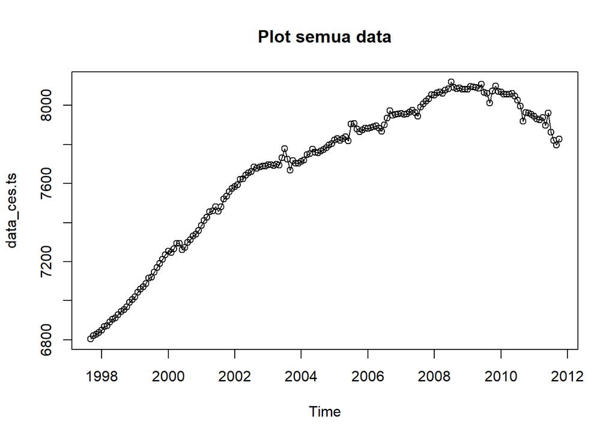

```r
plot(data_ces.ts, col="black",main="Plot semua data")
points(data_ces.ts)
```

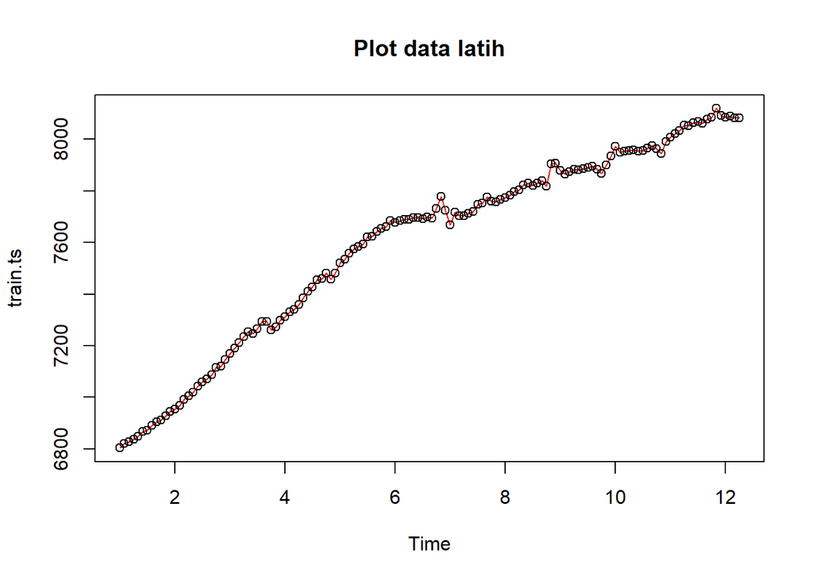

```r
plot(train.ts, col="red",main="Plot data latih")
points(train.ts)
```

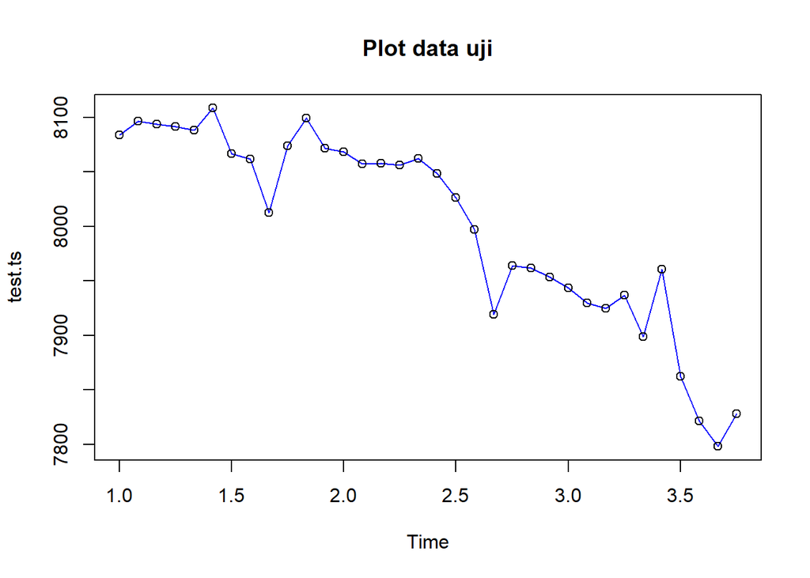

```r
plot(test.ts, col="blue",main="Plot data uji")
points(test.ts)
```

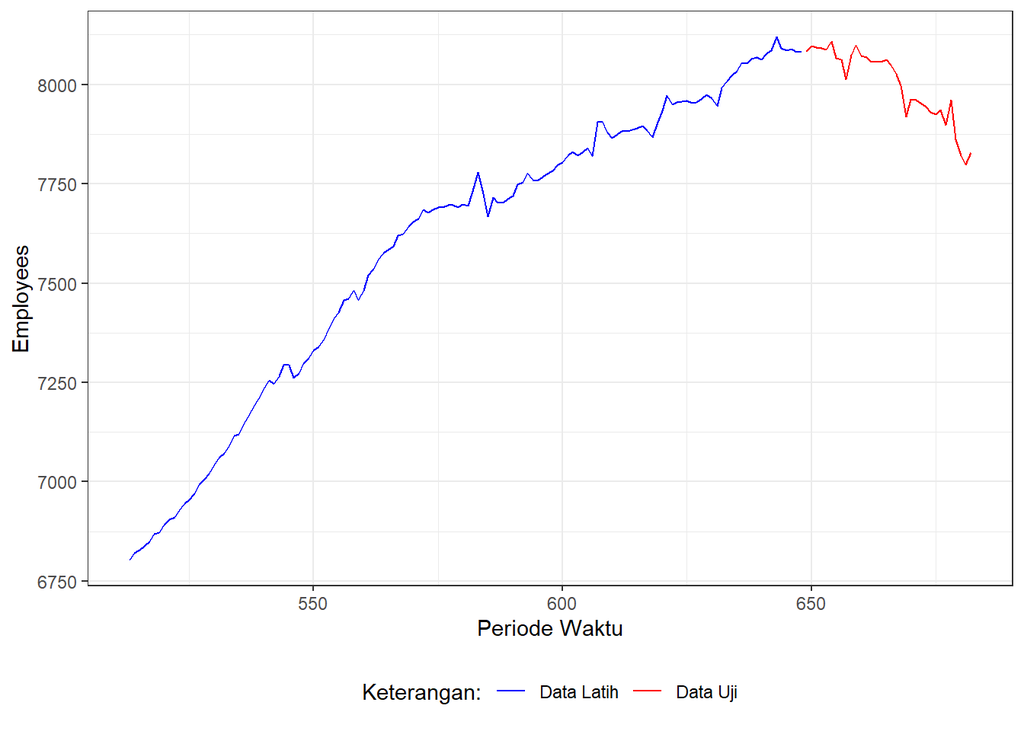

```r
#Eksplorasi dengan GGPLOT
ggplot() +
  geom_line(data = training, aes(x = Period, y = CES9093161101, col = "Data Latih")) +
  geom_line(data = testing, aes(x = Period, y = CES9093161101, col = "Data Uji")) +
  labs(x = "Periode Waktu", y = "Employees", color = "Legend") +
  scale_colour_manual(name="Keterangan:", breaks = c("Data Latih", "Data Uji"),
                      values = c("blue", "red")) +
  theme_bw() + theme(legend.position = "bottom",
                     plot.caption = element_text(hjust=0.5, size=12))
```

# Single Exponential Smoothing Single Exponential Smoothing (SES) adalah metode peramalan deret waktu yang dikembangkan untuk mengatasi kelemahan Moving Average. Jika pada Moving Average setiap data periode sebelumnya dianggap memiliki bobot yang sama, maka SES memberikan bobot yang semakin mengecil secara eksponensial terhadap data lama, sehingga data terbaru diberi bobot lebih besar.

Single Exponential Smoothing merupakan metode pemulusan yang tepat digunakan untuk data dengan pola stasioner atau konstan.

Nilai pemulusan pada periode ke-t didapat dari persamaan:

$$\tilde{y}_T=\lambda
y_t+(1-\lambda)\tilde{y}_{T-1}$$
Nilai parameter $\lambda$ adalah nilai antara 0 dan 1.

Nilai pemulusan periode ke-t bertindak sebagai nilai ramalan pada periode ke-$(T+\tau)$.

$$\tilde{y}_{T+\tau}(T)=\tilde{y}_T$$
Pemulusan dengan metode SES dapat dilakukan dengan dua fungsi dari *packages* berbeda, yaitu (1) fungsi `ses()` dari *packages* `forecast` dan (2) fungsi `HoltWinters` dari *packages* `stats` .

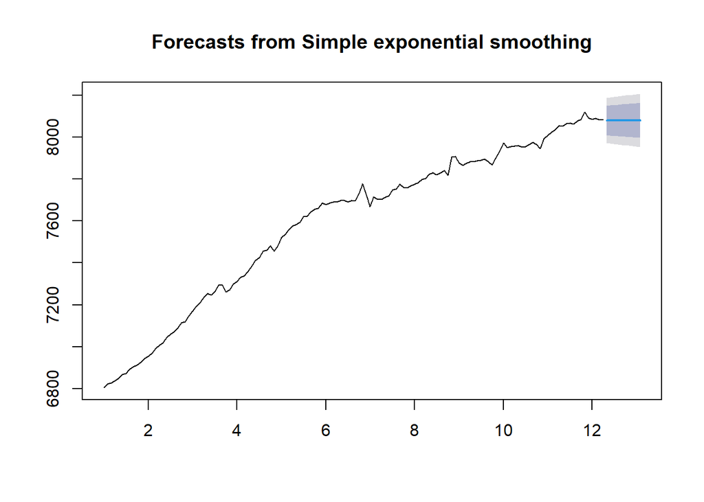

```r
#Cara 1 (fungsi ses)
ses.1 <- ses(train.ts, h = 10, alpha = 0.2)
plot(ses.1)
```

```r
ses.1
```

```
##        Point Forecast    Lo 80    Hi 80    Lo 95    Hi 95
## May 12       8079.855 8008.929 8150.782 7971.383 8188.328
## Jun 12       8079.855 8007.524 8152.186 7969.234 8190.476
## Jul 12       8079.855 8006.146 8153.564 7967.127 8192.583
## Aug 12       8079.855 8004.794 8154.917 7965.059 8194.652
## Sep 12       8079.855 8003.465 8156.245 7963.027 8196.684
## Oct 12       8079.855 8002.159 8157.551 7961.029 8198.681
## Nov 12       8079.855 8000.875 8158.836 7959.065 8200.645
## Dec 12       8079.855 7999.611 8160.099 7957.132 8202.578
## Jan 13       8079.855 7998.367 8161.344 7955.230 8204.481
## Feb 13       8079.855 7997.141 8162.569 7953.355 8206.355
```

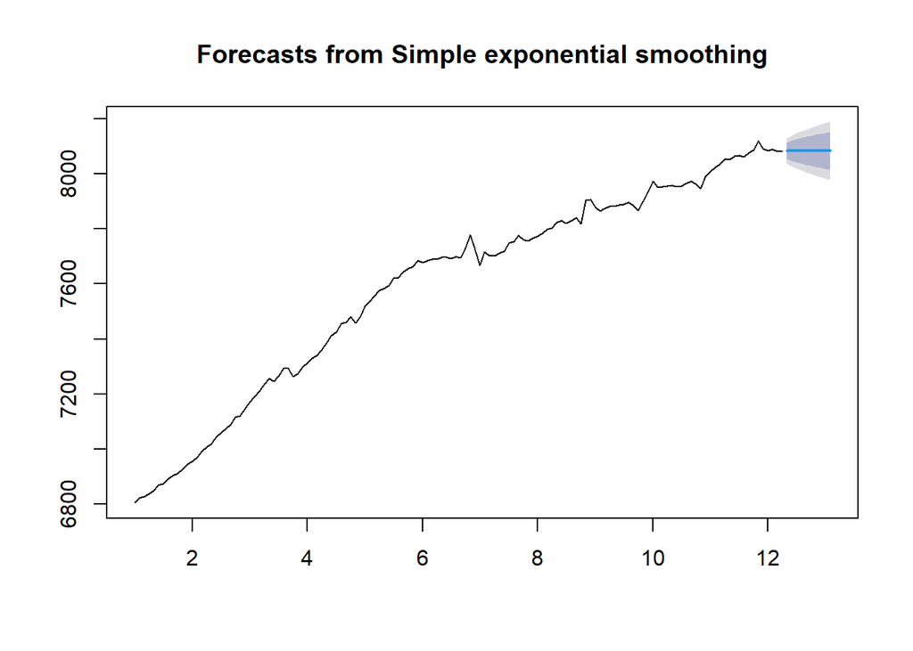

```r
ses.2<- ses(train.ts, h = 10, alpha = 0.7)
plot(ses.2)
```

```r
ses.2
```

```
##        Point Forecast    Lo 80    Hi 80    Lo 95    Hi 95
## May 12       8083.962 8054.330 8113.594 8038.643 8129.280
## Jun 12       8083.962 8047.791 8120.133 8028.643 8139.280
## Jul 12       8083.962 8042.266 8125.658 8020.193 8147.731
## Aug 12       8083.962 8037.391 8130.533 8012.738 8155.186
## Sep 12       8083.962 8032.981 8134.943 8005.993 8161.931
## Oct 12       8083.962 8028.922 8139.001 7999.786 8168.137
## Nov 12       8083.962 8025.143 8142.780 7994.007 8173.917
## Dec 12       8083.962 8021.593 8146.330 7988.577 8179.346
## Jan 13       8083.962 8018.234 8149.689 7983.440 8184.483
## Feb 13       8083.962 8015.039 8152.885 7978.553 8189.370
```

Pada fungsi `ses()` , terdapat beberapa argumen yang umum digunakan, yaitu

- `y` : nilai data deret waktu
- `alpha` : parameter pemulusan utama (0–1), mengatur bobot data terbaru vs data lama.
- `beta` : parameter pemulusan tren.
- `gamma` : parameter pemulusan musiman.
- `h` : jumlah periode ke depan yang ingin diramalkan (forecast horizon).

  Kasus di atas merupakan contoh inisialisasi nilai parameter $\lambda$ dengan nilai `alpha` 0,2 dan 0,7 dan banyak periode data yang akan diramalkan adalah sebanyak 10 periode.

Untuk mendapatkan gambar hasil pemulusan pada data latih dengan fungsi `ses()` , perlu digunakan fungsi `autoplot()` dan `autolayer()` dari *library packages* `ggplot2` .

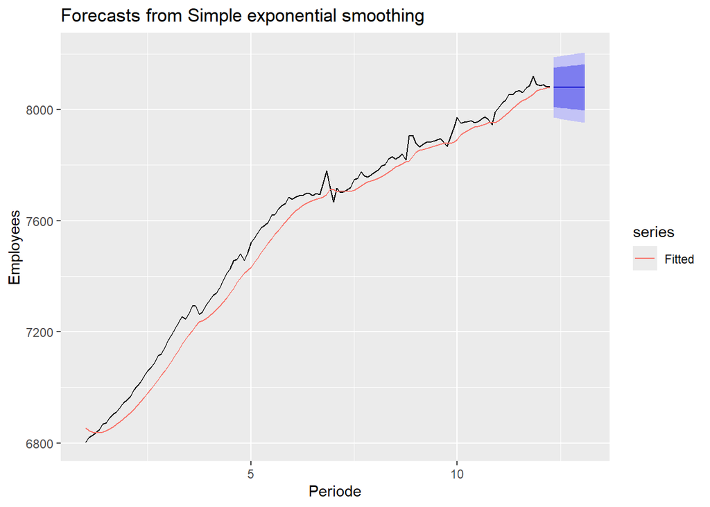

```r
autoplot(ses.1) +
  autolayer(fitted(ses.1), series="Fitted") +
  ylab("Employees") + xlab("Periode")
```

Selanjutnya akan digunakan fungsi HoltWinters() dengan nilai inisialisasi parameter dan panjang periode peramalan yang sama dengan fungsi ses() .

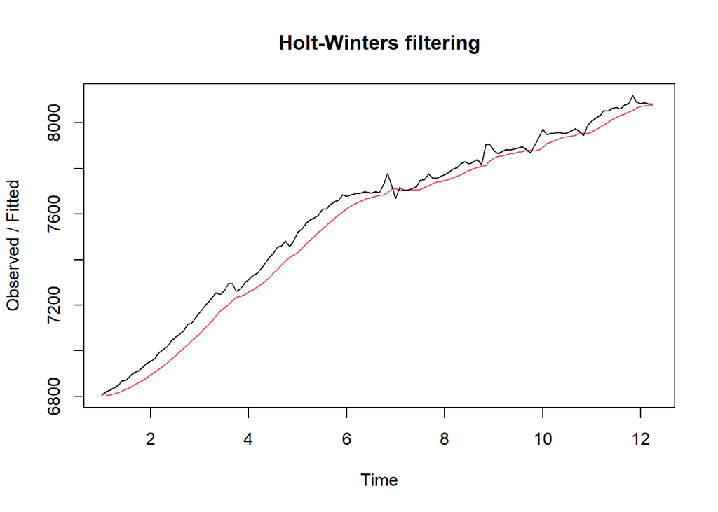

```r
#Cara 2 (fungsi Holtwinter)
ses1<- HoltWinters(train.ts, gamma = FALSE, beta = FALSE, alpha = 0.2)
plot(ses1)
```

```r
#ramalan
ramalan1<- forecast(ses1, h=10)
ramalan1
```

```
##        Point Forecast    Lo 80    Hi 80    Lo 95    Hi 95
## May 12       8079.855 8042.131 8117.579 8022.161 8137.549
## Jun 12       8079.855 8041.384 8118.326 8021.019 8138.692
## Jul 12       8079.855 8040.651 8119.059 8019.898 8139.813
## Aug 12       8079.855 8039.932 8119.779 8018.798 8140.913
## Sep 12       8079.855 8039.225 8120.485 8017.717 8141.994
## Oct 12       8079.855 8038.531 8121.180 8016.655 8143.056
## Nov 12       8079.855 8037.848 8121.863 8015.610 8144.101
## Dec 12       8079.855 8037.175 8122.535 8014.582 8145.128
## Jan 13       8079.855 8036.514 8123.197 8013.570 8146.141
## Feb 13       8079.855 8035.862 8123.849 8012.573 8147.137
```

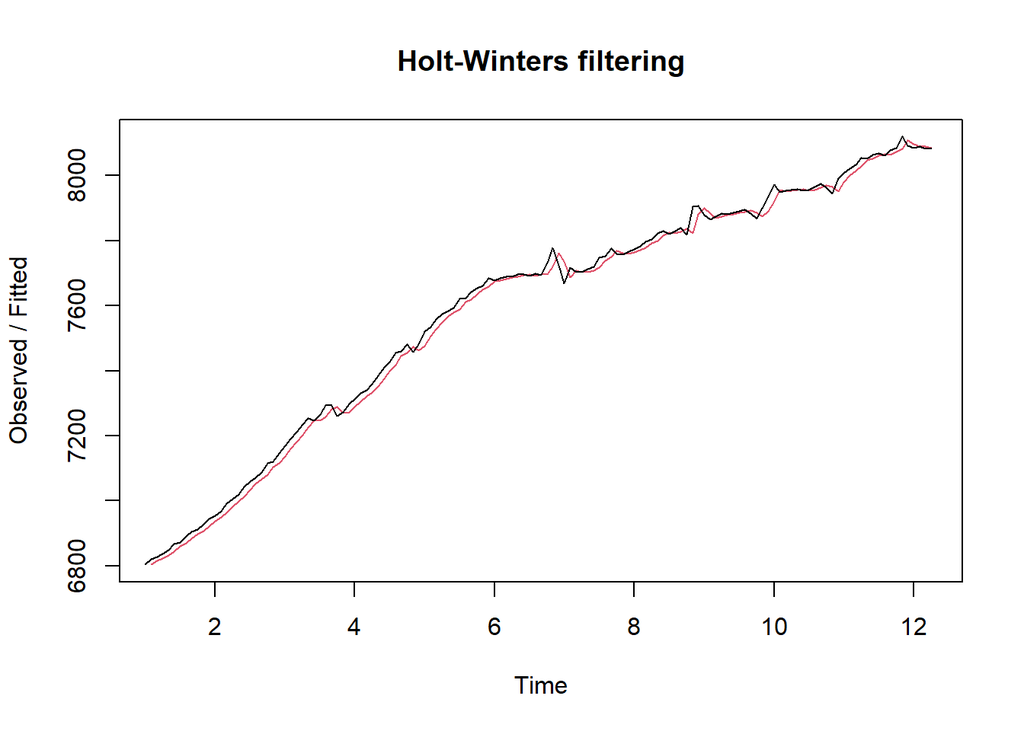

```r
ses2<- HoltWinters(train.ts, gamma = FALSE, beta = FALSE, alpha = 0.7)
plot(ses2)
```

```r
#ramalan
ramalan2<- forecast(ses2, h=10)
ramalan2
```

```
##        Point Forecast    Lo 80    Hi 80    Lo 95    Hi 95
## May 12       8083.962 8059.982 8107.941 8047.288 8120.635
## Jun 12       8083.962 8054.691 8113.233 8039.196 8128.728
## Jul 12       8083.962 8050.220 8117.704 8032.358 8135.566
## Aug 12       8083.962 8046.275 8121.649 8026.325 8141.599
## Sep 12       8083.962 8042.706 8125.218 8020.866 8147.057
## Oct 12       8083.962 8039.422 8128.502 8015.844 8152.080
## Nov 12       8083.962 8036.364 8131.560 8011.167 8156.757
## Dec 12       8083.962 8033.491 8134.433 8006.773 8161.151
## Jan 13       8083.962 8030.773 8137.151 8002.616 8165.308
## Feb 13       8083.962 8028.187 8139.737 7998.661 8169.262
```

Fungsi HoltWinters memiliki argumen yang sama dengan fungsi ses() . Argumen-argumen kedua fungsi dapat dilihat lebih lanjut dengan ?ses() atau ?HoltWinters .

Nilai parameter α dari kedua fungsi dapat dioptimalkan menyesuaikan dari error-nya paling minimumnya. Caranya adalah dengan membuat parameter α= NULL

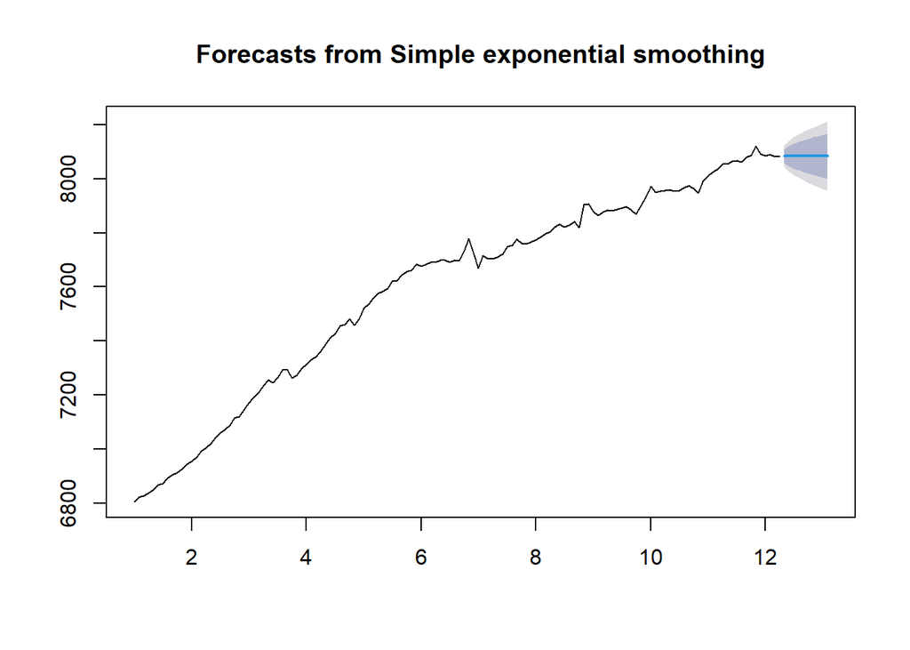

```r
#SES
ses.opt <- ses(train.ts, h = 10, alpha = NULL)
plot(ses.opt)
```

```r
ses.opt
```

```
##        Point Forecast    Lo 80    Hi 80    Lo 95    Hi 95
## May 12         8083.6 8057.251 8109.949 8043.302 8123.898
## Jun 12         8083.6 8046.338 8120.862 8026.613 8140.587
## Jul 12         8083.6 8037.965 8129.235 8013.807 8153.393
## Aug 12         8083.6 8030.905 8136.295 8003.010 8164.189
## Sep 12         8083.6 8024.686 8142.514 7993.498 8173.701
## Oct 12         8083.6 8019.063 8148.137 7984.899 8182.301
## Nov 12         8083.6 8013.892 8153.308 7976.991 8190.209
## Dec 12         8083.6 8009.079 8158.121 7969.630 8197.569
## Jan 13         8083.6 8004.559 8162.641 7962.717 8204.483
## Feb 13         8083.6 8000.284 8166.916 7956.179 8211.021
```

```r
#Lamda Optimum Holt Winter
HWopt<- HoltWinters(train.ts, gamma = FALSE, beta = FALSE,alpha = NULL)
HWopt
```

```
## Holt-Winters exponential smoothing without trend and without seasonal component.
##
## Call:
## HoltWinters(x = train.ts, alpha = NULL, beta = FALSE, gamma = FALSE)
##
## Smoothing parameters:
##  alpha: 0.9999459
##  beta : FALSE
##  gamma: FALSE
##
## Coefficients:
##     [,1]
## a 8083.6
```

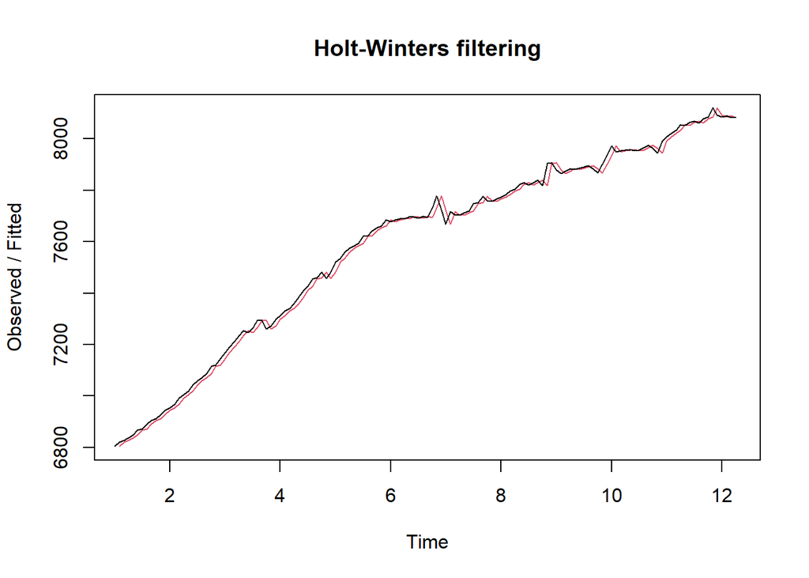

```r
plot(HWopt)
```

```r
#ramalan
ramalanopt<- forecast(HWopt, h=34)
ramalanopt
```

```
##        Point Forecast    Lo 80    Hi 80    Lo 95    Hi 95
## May 12         8083.6 8060.242 8106.958 8047.877 8119.323
## Jun 12         8083.6 8050.567 8116.632 8033.081 8134.119
## Jul 12         8083.6 8043.144 8124.056 8021.728 8145.472
## Aug 12         8083.6 8036.886 8130.314 8012.157 8155.043
## Sep 12         8083.6 8031.372 8135.828 8003.724 8163.476
## Oct 12         8083.6 8026.387 8140.813 7996.100 8171.100
## Nov 12         8083.6 8021.803 8145.397 7989.090 8178.110
## Dec 12         8083.6 8017.536 8149.664 7982.564 8184.636
## Jan 13         8083.6 8013.529 8153.671 7976.436 8190.764
## Feb 13         8083.6 8009.739 8157.461 7970.639 8196.561
## Mar 13         8083.6 8006.134 8161.066 7965.125 8202.074
## Apr 13         8083.6 8002.689 8164.511 7959.857 8207.342
## May 13         8083.6 7999.385 8167.815 7954.805 8212.395
## Jun 13         8083.6 7996.206 8170.994 7949.943 8217.257
## Jul 13         8083.6 7993.139 8174.061 7945.252 8221.948
## Aug 13         8083.6 7990.172 8177.028 7940.715 8226.485
## Sep 13         8083.6 7987.297 8179.903 7936.317 8230.883
## Oct 13         8083.6 7984.505 8182.695 7932.047 8235.153
## Nov 13         8083.6 7981.789 8185.410 7927.894 8239.306
## Dec 13         8083.6 7979.145 8188.055 7923.849 8243.351
## Jan 14         8083.6 7976.565 8190.635 7919.904 8247.296
## Feb 14         8083.6 7974.046 8193.154 7916.052 8251.148
## Mar 14         8083.6 7971.584 8195.616 7912.287 8254.913
## Apr 14         8083.6 7969.175 8198.025 7908.602 8258.598
## May 14         8083.6 7966.815 8200.385 7904.993 8262.207
## Jun 14         8083.6 7964.503 8202.697 7901.456 8265.744
## Jul 14         8083.6 7962.234 8204.966 7897.987 8269.213
## Aug 14         8083.6 7960.007 8207.193 7894.581 8272.619
## Sep 14         8083.6 7957.819 8209.381 7891.235 8275.965
## Oct 14         8083.6 7955.669 8211.531 7887.946 8279.254
## Nov 14         8083.6 7953.554 8213.646 7884.712 8282.488
## Dec 14         8083.6 7951.473 8215.727 7881.530 8285.670
## Jan 15         8083.6 7949.425 8217.775 7878.397 8288.803
## Feb 15         8083.6 7947.407 8219.793 7875.311 8291.889
```

Setelah dilakukan peramalan, akan dilakukan perhitungan keakuratan hasil peramalan. Perhitungan akurasi ini dilakukan baik pada data latih dan data uji.

# Akurasi Data Latih

Perhitungan akurasi data dapat dilakukan dengan cara langsung maupun manual. Secara langsung, nilai akurasi dapat diambil dari objek yang tersimpan pada hasil SES, yaitu *sum of squared errors* (SSE). Nilai akurasi lain dapat dihitung pula dari nilai SSE tersebut.

```r
#Keakuratan Metode
#Pada data training

# SES dengan alpha = 0.2
SSE1<-ses1$SSE
MSE1<-ses1$SSE/length(train.ts)
RMSE1<-sqrt(MSE1)

akurasi1 <- matrix(c(SSE1,MSE1,RMSE1))
row.names(akurasi1)<- c("SSE", "MSE", "RMSE")
colnames(akurasi1) <- c("Akurasi lamda=0.2")
akurasi1
```

```
##      Akurasi lamda=0.2
## SSE       417555.42408
## MSE         3070.26047
## RMSE          55.40993
```

```r
# SES dengan alpha = 0.7
SSE2<-ses2$SSE
MSE2<-ses2$SSE/length(train.ts)
RMSE2<-sqrt(MSE2)

akurasi2 <- matrix(c(SSE2,MSE2,RMSE2))
row.names(akurasi2)<- c("SSE", "MSE", "RMSE")
colnames(akurasi2) <- c("Akurasi lamda=0.7")
akurasi2
```

```
##      Akurasi lamda=0.7
## SSE        71681.72998
## MSE          527.07154
## RMSE          22.95804
```

```r
#Cara Manual
# Alpha = 0.2
fitted1<-ramalan1$fitted
sisaan1<-ramalan1$residuals
head(sisaan1)
```

```
##     Jan   Feb   Mar   Apr   May   Jun
## 1    NA 17.00 20.00 25.50 32.80 44.44
```

```r
resid1<-training$CES9093161101-ramalan1$fitted
head(resid1)
```

```
##     Jan   Feb   Mar   Apr   May   Jun
## 1    NA 17.00 20.00 25.50 32.80 44.44
```

```r
SSE.1=sum(sisaan1[2:length(train.ts)]^2)
SSE.1
```

```
## [1] 417555.4
```

```r
MSE.1 = SSE.1/length(train.ts)
MSE.1
```

```
## [1] 3070.26
```

```r
MAPE.1 = sum(abs(sisaan1[2:length(train.ts)]/train.ts[2:length(train.ts)])*
               100)/length(train.ts)
MAPE.1
```

```
## [1] 0.6412236
```

```r
akurasi.1 <- matrix(c(SSE.1,MSE.1,MAPE.1))
row.names(akurasi.1)<- c("SSE", "MSE", "MAPE")
colnames(akurasi.1) <- c("Akurasi lamda=0.2")
akurasi.1
```

```
##      Akurasi lamda=0.2
## SSE       4.175554e+05
## MSE       3.070260e+03
## MAPE      6.412236e-01
```

```r
# Alpha = 0.7
fitted2<-ramalan2$fitted
sisaan2<-ramalan2$residuals
head(sisaan2)
```

```
##       Jan     Feb     Mar     Apr     May     Jun
## 1      NA 17.0000 11.5000 12.9500 16.2850 23.0855
```

```r
resid2<-training$CES9093161101-ramalan1$fitted
head(resid2)
```

```
##     Jan   Feb   Mar   Apr   May   Jun
## 1    NA 17.00 20.00 25.50 32.80 44.44
```

```r
SSE.2=sum(sisaan2[2:length(train.ts)]^2)
SSE.2
```

```
## [1] 71681.73
```

```r
MSE.2 = SSE.2/length(train.ts)
MSE.2
```

```
## [1] 527.0715
```

```r
MAPE.2 = sum(abs(sisaan2[2:length(train.ts)]/train.ts[2:length(train.ts)])*
               100)/length(train.ts)
MAPE.2
```

```
## [1] 0.2465846
```

```r
akurasi.2 <- matrix(c(SSE.2,MSE.2,MAPE.2))
row.names(akurasi.2)<- c("SSE", "MSE", "MAPE")
colnames(akurasi.2) <- c("Akurasi lamda=0.7")
akurasi.2
```

```
##      Akurasi lamda=0.7
## SSE       7.168173e+04
## MSE       5.270715e+02
## MAPE      2.465846e-01
```

# Akurasi Data Uji

Akurasi data uji dapat dihitung dengan cara yang hampir sama dengan perhitungan akurasi data latih.

```r
# Akurasi Data Uji

# Jumlah observasi uji
n_test <- nrow(testing)

# Data aktual
aktual_test <- as.numeric(testing$CES9093161101)

# Forecast 35 periode ke depan
ramalan1_test <- forecast(ses1, h = n_test)
ramalan2_test <- forecast(ses2, h = n_test)
ramalanopt_test <- forecast(HWopt, h = n_test)

# Error (ramalan - aktual)
e1 <- as.numeric(ramalan1_test$mean) - aktual_test
e2 <- as.numeric(ramalan2_test$mean) - aktual_test
eopt <- as.numeric(ramalanopt_test$mean) - aktual_test

# SSE
SSEtesting1 <- sum(e1^2)
SSEtesting2 <- sum(e2^2)
SSEtestingopt <- sum(eopt^2)

# MSE
MSEtesting1 <- mean(e1^2)
MSEtesting2 <- mean(e2^2)
MSEtestingopt <- mean(eopt^2)

# RMSE
RMSEtesting1 <- sqrt(MSEtesting1)
RMSEtesting2 <- sqrt(MSEtesting2)
RMSEtestingopt <- sqrt(MSEtestingopt)

# Tabel SSE
akurasitesting_SSE <- matrix(
  c(SSEtesting1, SSEtesting2, SSEtestingopt),
  nrow = 3,
  dimnames = list(
    c("SSE1", "SSE2", "SSEopt"),
    "Nilai"
  )
)

# Tabel MSE
akurasitesting_MSE <- matrix(
  c(MSEtesting1, MSEtesting2, MSEtestingopt),
  nrow = 3,
  dimnames = list(
    c("MSE1", "MSE2", "MSEopt"),
    "Nilai"
  )
)

# Tabel RMSE
akurasitesting_RMSE <- matrix(
  c(RMSEtesting1, RMSEtesting2, RMSEtestingopt),
  nrow = 3,
  dimnames = list(
    c("RMSE1", "RMSE2", "RMSEopt"),
    "Nilai"
  )
)

# Tampilkan hasil
akurasitesting_SSE
```

```
##           Nilai
## SSE1   479005.3
## SSE2   501688.2
## SSEopt 499643.3
```

```r
akurasitesting_MSE
```

```
##           Nilai
## MSE1   14088.39
## MSE2   14755.53
## MSEopt 14695.39
```

```r
akurasitesting_RMSE
```

```
##            Nilai
## RMSE1   118.6945
## RMSE2   121.4724
## RMSEopt 121.2245
```

Selain dengan cara di atas, perhitungan nilai akurasi dapat menggunakan fungsi accuracy() dari package forecast . Penggunaannya yaitu dengan menuliskan accuracy(hasil ramalan, kondisi aktual) . Contohnya adalah sebagai berikut.

```r
# Forecast sebanyak jumlah data uji
ramalan1_test <- forecast(ses1, h = nrow(testing))
ramalan2_test <- forecast(ses2, h = nrow(testing))
ramalanopt_test <- forecast(HWopt, h = nrow(testing))

# Akurasi data uji
accuracy(ramalan1_test, testing$CES9093161101)
```

```
##                     ME      RMSE      MAE       MPE      MAPE     MASE
## Training set  47.25390  55.61477 48.37805  0.631446 0.6459734 3.036279
## Test set     -79.17587 118.69453 85.21781 -1.002052 1.0766601 5.348398
##                   ACF1
## Training set 0.7745167
## Test set            NA
```

```r
accuracy(ramalan2_test, testing$CES9093161101)
```

```
##                     ME      RMSE      MAE        MPE      MAPE     MASE
## Training set  13.54457  23.04291 18.71391  0.1817983 0.2484112 1.174513
## Test set     -83.28242 121.47236 87.63343 -1.0533855 1.1071041 5.500006
##                   ACF1
## Training set 0.2361474
## Test set            NA
```

```r
accuracy(ramalanopt_test, testing$CES9093161101)
```

```
##                      ME     RMSE      MAE        MPE      MAPE     MASE
## Training set   9.479031  20.4840 15.93369  0.1272948 0.2105414 1.000022
## Test set     -82.920545 121.2245 87.42056 -1.0488619 1.1044213 5.486646
##                     ACF1
## Training set -0.01382782
## Test set              NA
```

# *Double Exponential Smoothing* (DES)

Metode pemulusan *Double Exponential Smoothing* (DES) digunakan untuk data yang memiliki pola tren. Metode DES adalah metode semacam SES, hanya saja dilakukan dua kali, yaitu pertama untuk tahapan ‘level’ dan kedua untuk tahapan ‘tren’. Pemulusan menggunakan metode ini akan menghasilkan peramalan tidak konstan untuk periode berikutnya.

Pemulusan dengan metode DES kali ini akan menggunakan fungsi `HoltWinters()` . Jika sebelumnya nilai argumen `beta` dibuat `FALSE` , kali ini argumen tersebut akan diinisialisasi bersamaan dengan nilai `alpha` .

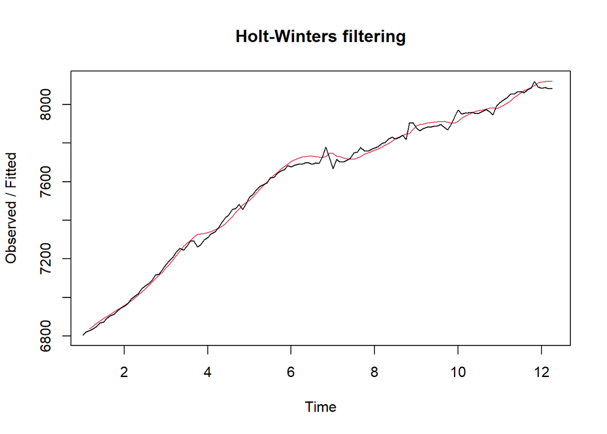

```r
#Alpha=0.2 dan gamma=0.2
des.1<- HoltWinters(train.ts, gamma = FALSE, beta = 0.2, alpha = 0.2)
plot(des.1)
```

```r
#ramalan
ramalandes1<- forecast(des.1, h=34)
ramalandes1
```

```
##        Point Forecast    Lo 80    Hi 80    Lo 95    Hi 95
## May 12       8115.852 8085.114 8146.589 8068.843 8162.861
## Jun 12       8119.941 8088.331 8151.552 8071.597 8168.285
## Jul 12       8124.031 8091.270 8156.792 8073.927 8174.135
## Aug 12       8128.121 8093.915 8162.327 8075.807 8180.434
## Sep 12       8132.211 8096.259 8168.162 8077.228 8187.193
## Oct 12       8136.300 8098.305 8174.296 8078.191 8194.409
## Nov 12       8140.390 8100.059 8180.721 8078.709 8202.071
## Dec 12       8144.480 8101.535 8187.424 8078.801 8210.158
## Jan 13       8148.569 8102.747 8194.392 8078.490 8218.649
## Feb 13       8152.659 8103.710 8201.608 8077.798 8227.520
## Mar 13       8156.749 8104.441 8209.057 8076.751 8236.747
## Apr 13       8160.839 8104.954 8216.724 8075.370 8246.307
## May 13       8164.928 8105.263 8224.594 8073.677 8256.179
## Jun 13       8169.018 8105.380 8232.656 8071.692 8266.344
## Jul 13       8173.108 8105.318 8240.898 8069.432 8276.784
## Aug 13       8177.198 8105.085 8249.310 8066.911 8287.484
## Sep 13       8181.287 8104.692 8257.883 8064.145 8298.430
## Oct 13       8185.377 8104.146 8266.608 8061.145 8309.609
## Nov 13       8189.467 8103.454 8275.479 8057.922 8321.012
## Dec 13       8193.556 8102.623 8284.490 8054.486 8332.627
## Jan 14       8197.646 8101.658 8293.634 8050.845 8344.447
## Feb 14       8201.736 8100.565 8302.907 8047.008 8356.464
## Mar 14       8205.826 8099.348 8312.304 8042.981 8368.670
## Apr 14       8209.915 8098.010 8321.821 8038.771 8381.059
## May 14       8214.005 8096.557 8331.453 8034.384 8393.627
## Jun 14       8218.095 8094.991 8341.199 8029.824 8406.366
## Jul 14       8222.185 8093.315 8351.054 8025.096 8419.273
## Aug 14       8226.274 8091.533 8361.016 8020.205 8432.344
## Sep 14       8230.364 8089.646 8371.082 8015.155 8445.573
## Oct 14       8234.454 8087.658 8381.250 8009.949 8458.959
## Nov 14       8238.544 8085.570 8391.517 8004.591 8472.496
## Dec 14       8242.633 8083.385 8401.881 7999.084 8486.182
## Jan 15       8246.723 8081.105 8412.341 7993.432 8500.014
## Feb 15       8250.813 8078.731 8422.895 7987.636 8513.990
```

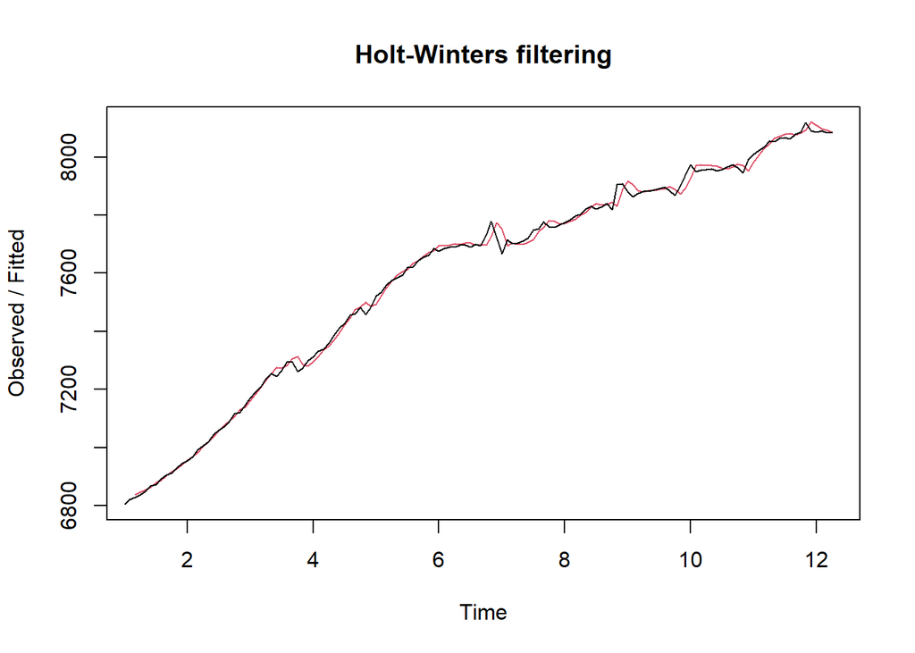

```r
#Alpha=0.6 dan gamma=0.3
des.2<- HoltWinters(train.ts, gamma = FALSE, beta = 0.3, alpha = 0.6)
plot(des.2)
```

```r
#ramalan
ramalandes2<- forecast(des.2, h=34)
ramalandes2
```

```
##        Point Forecast    Lo 80    Hi 80    Lo 95    Hi 95
## May 12       8083.064 8057.782 8108.347 8044.398 8121.730
## Jun 12       8081.534 8049.470 8113.598 8032.497 8130.571
## Jul 12       8080.004 8039.790 8120.218 8018.502 8141.506
## Aug 12       8078.474 8028.998 8127.950 8002.807 8154.141
## Sep 12       8076.944 8017.265 8136.623 7985.673 8168.215
## Oct 12       8075.414 8004.705 8146.123 7967.273 8183.554
## Nov 12       8073.884 7991.398 8156.369 7947.733 8200.034
## Dec 12       8072.354 7977.405 8167.302 7927.142 8217.565
## Jan 13       8070.824 7962.771 8178.876 7905.572 8236.075
## Feb 13       8069.294 7947.533 8191.054 7883.078 8255.509
## Mar 13       8067.763 7931.722 8203.805 7859.706 8275.821
## Apr 13       8066.233 7915.362 8217.104 7835.496 8296.970
## May 13       8064.703 7898.477 8230.930 7810.482 8318.924
## Jun 13       8063.173 7881.085 8245.261 7784.693 8341.653
## Jul 13       8061.643 7863.203 8260.083 7758.156 8365.130
## Aug 13       8060.113 7844.848 8275.378 7730.893 8389.333
## Sep 13       8058.583 7826.032 8291.134 7702.927 8414.239
## Oct 13       8057.053 7806.768 8307.338 7674.275 8439.830
## Nov 13       8055.523 7787.068 8323.977 7644.957 8466.088
## Dec 13       8053.993 7766.943 8341.042 7614.988 8492.997
## Jan 14       8052.463 7746.402 8358.523 7584.384 8520.541
## Feb 14       8050.933 7725.455 8376.410 7553.158 8548.707
## Mar 14       8049.402 7704.110 8394.695 7521.324 8577.481
## Apr 14       8047.872 7682.376 8413.369 7488.893 8606.851
## May 14       8046.342 7660.259 8432.426 7455.878 8636.806
## Jun 14       8044.812 7637.767 8451.858 7422.290 8667.334
## Jul 14       8043.282 7614.906 8471.658 7388.138 8698.426
## Aug 14       8041.752 7591.684 8491.820 7353.432 8730.072
## Sep 14       8040.222 7568.106 8512.338 7318.182 8762.261
## Oct 14       8038.692 7544.177 8533.207 7282.397 8794.987
## Nov 14       8037.162 7519.904 8554.420 7246.084 8828.240
## Dec 14       8035.632 7495.291 8575.973 7209.252 8862.012
## Jan 15       8034.102 7470.343 8597.860 7171.908 8896.296
## Feb 15       8032.572 7445.066 8620.077 7134.059 8931.084
```

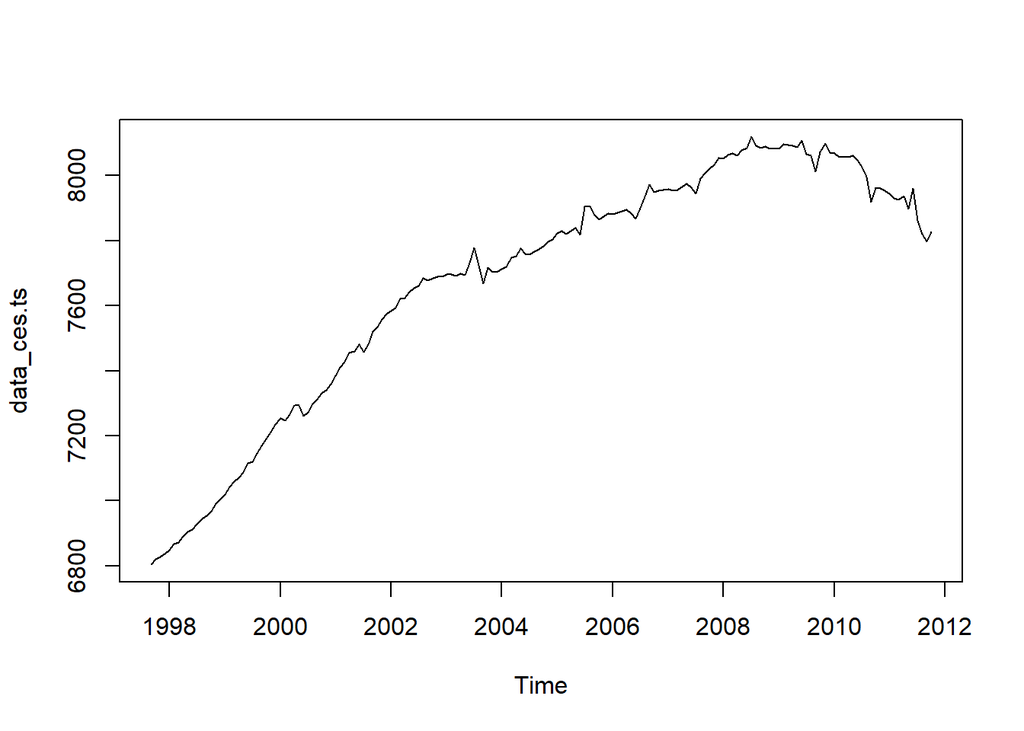

```r
plot(data_ces.ts)
lines(des.1$fitted[,1], lty=2, col="blue")
lines(ramalandes1$mean, col="red")
```

Untuk mendapatkan nilai parameter optimum dari DES, argumen `alpha` dan `beta` dapat dibuat `NULL` seperti berikut.

```r
#Lamda dan gamma optimum
des.opt<- HoltWinters(train.ts, gamma = FALSE)
des.opt
```

```
## Holt-Winters exponential smoothing with trend and without seasonal component.
##
## Call:
## HoltWinters(x = train.ts, gamma = FALSE)
##
## Smoothing parameters:
##  alpha: 0.8996806
##  beta : 0.04118656
##  gamma: FALSE
##
## Coefficients:
##          [,1]
## a 8084.237397
## b    5.548493
```

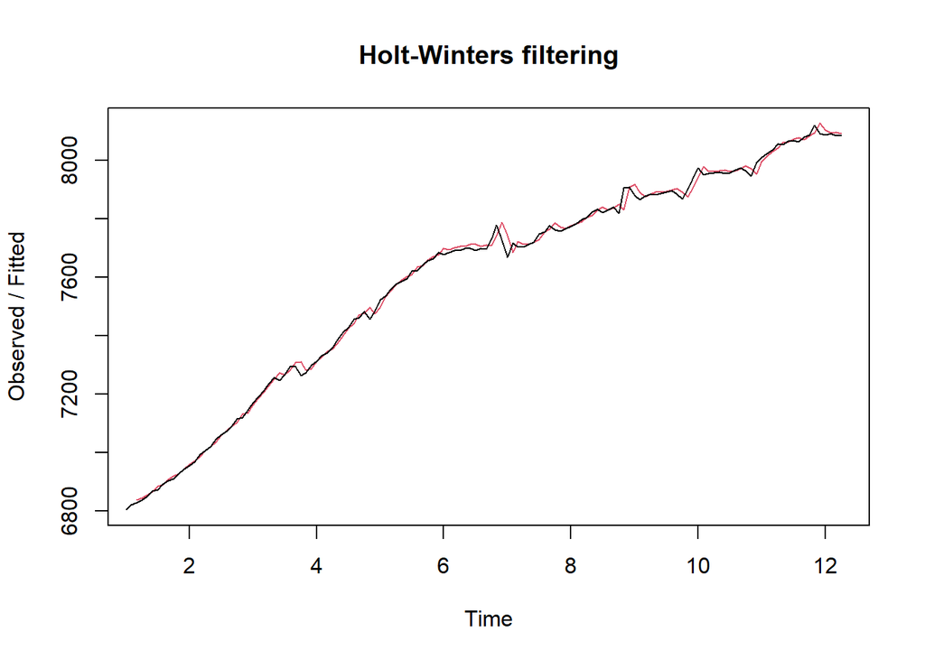

```r
plot(des.opt)
```

```r
#ramalan
ramalandesopt<- forecast(des.opt, h=34)
ramalandesopt
```

```
##        Point Forecast    Lo 80    Hi 80    Lo 95    Hi 95
## May 12       8089.786 8066.574 8112.998 8054.286 8125.285
## Jun 12       8095.334 8063.529 8127.139 8046.693 8143.976
## Jul 12       8100.883 8061.864 8139.902 8041.209 8160.557
## Aug 12       8106.431 8060.901 8151.962 8036.799 8176.064
## Sep 12       8111.980 8060.360 8163.600 8033.033 8190.926
## Oct 12       8117.528 8060.093 8174.964 8029.688 8205.369
## Nov 12       8123.077 8060.012 8186.142 8026.628 8219.526
## Dec 12       8128.625 8060.062 8197.189 8023.766 8233.484
## Jan 13       8134.174 8060.202 8208.146 8021.044 8247.304
## Feb 13       8139.722 8060.405 8219.039 8018.418 8261.027
## Mar 13       8145.271 8060.651 8229.891 8015.856 8274.685
## Apr 13       8150.819 8060.923 8240.715 8013.335 8288.303
## May 13       8156.368 8061.210 8251.526 8010.837 8301.899
## Jun 13       8161.916 8061.501 8262.331 8008.345 8315.487
## Jul 13       8167.465 8061.790 8273.140 8005.849 8329.081
## Aug 13       8173.013 8062.069 8283.957 8003.339 8342.688
## Sep 13       8178.562 8062.334 8294.789 8000.807 8356.317
## Oct 13       8184.110 8062.581 8305.640 7998.247 8369.974
## Nov 13       8189.659 8062.805 8316.513 7995.653 8383.665
## Dec 13       8195.207 8063.004 8327.410 7993.020 8397.394
## Jan 14       8200.756 8063.176 8338.335 7990.346 8411.165
## Feb 14       8206.304 8063.319 8349.290 7987.627 8424.982
## Mar 14       8211.853 8063.430 8360.276 7984.860 8438.846
## Apr 14       8217.401 8063.508 8371.294 7982.042 8452.760
## May 14       8222.950 8063.553 8382.347 7979.173 8466.727
## Jun 14       8228.498 8063.562 8393.435 7976.250 8480.747
## Jul 14       8234.047 8063.535 8404.558 7973.272 8494.822
## Aug 14       8239.595 8063.471 8415.719 7970.237 8508.953
## Sep 14       8245.144 8063.370 8426.917 7967.145 8523.142
## Oct 14       8250.692 8063.231 8438.153 7963.996 8537.389
## Nov 14       8256.241 8063.054 8449.428 7960.787 8551.695
## Dec 14       8261.789 8062.837 8460.741 7957.518 8566.060
## Jan 15       8267.338 8062.581 8472.094 7954.190 8580.485
## Feb 15       8272.886 8062.286 8483.486 7950.801 8594.971
```